# Some Background on Tree Models

Elisa Wirsching

March 23, 2023

# What Problem are We Trying to Solve?

- split data in smaller and smaller groups based on predictors, attempting to make each as “homogenous” in $Y$ as possible
- idea: partition the space of predictors into $(R_1, ..., R_j)$ non-overlapping sets (similar to binning)

# Recursive Binary Splitting

- How do we construct regions $R_1, ..., R_j$?
- Goal is to find boxes $R_1, ..., R_j$ that minimize loss function, e.g. RSS:
  $$\begin{align}
  \sum_{j=1}^J \sum_{i \in R_j} (y_i-\hat{y}_{R_j})^2
  \end{align}$$
- But it is impossible to check all partition into $J$ boxes
- We therefore use recursive binary splitting:
  - Split predictor space on one dimension into two sets
  - Split each of the resulting resulting sets into two sets again
  - Repeat until you have only a small number of observations left in each of the terminal sets
- This algorithm is top down and greedy: best split is made at that particular step, rather than looking ahead and ensure better split in some future step

# Example of Regression Tree

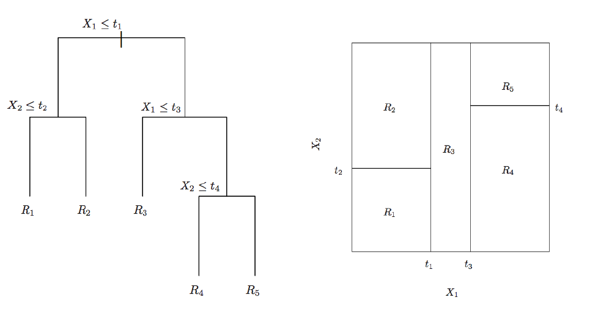

Regression Tree

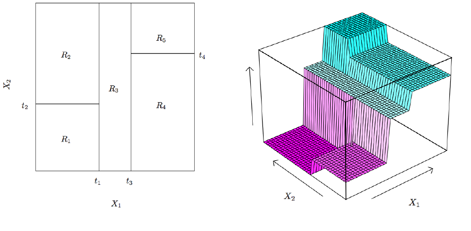

Prediction Surface

# Example of Classification Tree

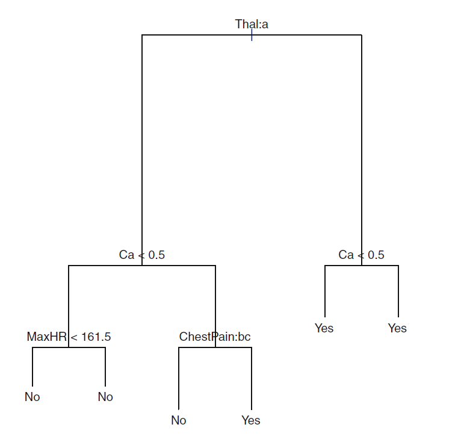

Classification Tree

- $\hat{y}_{R_m}$ can no longer be the average outcome in a region $R_m$ $\to$ most frequent outome category for the observations in set $R_m$
- RSS can no longer be used as a criterion for making binary splits
  - Classification error: $1 - \max_k (\hat{p}_{mk})$; ${p}_{mk}$ is proportion of observations in $R_m$ that are from class $k$ $\to$ fraction of training observations that do not belong to most common class;
  - Gini index: $\sum_{k=1}^K \hat{p}_{mk} (1- \hat{p}_{mk})$; measure of total variance across $K$ classes $\to$ measure of *node purity* (small value indicates that node contains predominantly observations from a single class)
  - Entropy: $- \sum_{k=1}^K \hat{p}_{mk}\log \hat{p}_{mk}$

# Tree Pruning

- Problem of a simple tree: Complex trees lead to low bias, but high variance of predictions and worse interpretability
- We can prune large trees: Penalize tree complexity (conditional optimization)
  - $\sum_{m=1}^{|T|} \sum_{i:x_i \in R_m} (y_i - \hat{y}_{R_m})^2 + \alpha |T|$

# Bagging

- The problem with simple (though pruned) tree is: sensitivity to small perturbations in the data which lead to huge differences in predictions $\to$ high variance
- Bagging combines predictions from multiple regression trees to reduce variance of predictions
- Description of algorithm
  - Take a bootstrap sample $b = 1, ...,B$ from training set (with replacement)
  - Estimate a deep regression tree for sample $b$ (without pruning)
  - Estimate prediction $\hat{g}^b(\mathbf{x})$ for that tree
  - Calculate ensemble prediction
    $$\begin{align}
    \hat{g}(\mathbf{x}) = \sum_{b=1}^B \hat{g}^b(\mathbf{x}) / B
    \end{align}$$
- Averaging over a large number of high-variance low-bias trees results in lower-variance bag of trees

## Random Forest

- Cool, but we can do even better! Why?
  - Each tree is too similar $\to$ induces correlation btw trees and thus higher variance
  - Bagging is computationally complex
- Random Forest
  - Take a bootstrap sample $b = 1, ..., B$ from training set (with replacement)
  - Build regression tree by randomly selecting $m<p$ predictors (usually $m \approx \sqrt{p}$)
  - Estimate prediction $\hat{g}^b(\mathbf{x})$ for that tree
  - Calculate *ensemble* prediction
    $$\begin{align}
    \hat{g}(\mathbf{x}) = \sum_{b=1}^B \hat{g}^b(\mathbf{x}) / B
    \end{align}$$

## Boosting

- Ensemble methods combine multiple models
- Parallel ensembles
  - each model is built independently
  - e.g. bagging and random forest
  - main idea: combine many (high complexity, low bias) models to reduce variance
- Sequential ensembles
  - models are generated sequentially
  - try to add new models that do well where previous models lacked
  - instead of bootstrapping the data, we fit a tree using the current residuals rather than outcome $Y$

These examples and explanations are inspired by [James et al. 2017, An Introduction to Statistical Learning with Applications in R](https://www.statlearning.com/).